# Bellabeat_case_study

# 3 Process and Analyze

**3.0 Formatting: Changing the date format, making the tables compatible for a successful merge.**

```r
# Formatting 'activity1' table
activity1$activity_date <- as.POSIXct(activity1$activity_date, format = "%m/%d/%Y", tz = Sys.timezone())
activity1$date <- format(activity1$activity_date, format = "%m/%d/%y")

# Formatting 'sleepday1' table
sleepday1$sleep_day <- as.POSIXct(sleepday1$sleep_day, format = "%m/%d/%Y %I:%M:%S %p", tz = Sys.timezone())
sleepday1$date <- format(sleepday1$sleep_day, format = "%m/%d/%y")

head(activity1)
```

```
##           id activity_date total_steps total_distance tracker_distance
## 1 1503960366    2016-04-12       13162           8.50             8.50
## 2 1503960366    2016-04-13       10735           6.97             6.97
## 3 1503960366    2016-04-14       10460           6.74             6.74
## 4 1503960366    2016-04-15        9762           6.28             6.28
## 5 1503960366    2016-04-16       12669           8.16             8.16
## 6 1503960366    2016-04-17        9705           6.48             6.48
##   logged_activities_distance very_active_distance moderately_active_distance
## 1                          0                 1.88                       0.55
## 2                          0                 1.57                       0.69
## 3                          0                 2.44                       0.40
## 4                          0                 2.14                       1.26
## 5                          0                 2.71                       0.41
## 6                          0                 3.19                       0.78
##   light_active_distance sedentary_active_distance very_active_minutes
```

[output cut: 20 more lines]

```r
head(sleepday1)
```

```
##           id  sleep_day total_sleep_records total_minutes_asleep
## 1 1503960366 2016-04-12                   1                  327
## 2 1503960366 2016-04-13                   2                  384
## 3 1503960366 2016-04-15                   1                  412
## 4 1503960366 2016-04-16                   2                  340
## 5 1503960366 2016-04-17                   1                  700
## 6 1503960366 2016-04-19                   1                  304
##   total_time_in_bed     date
## 1               346 04/12/16
## 2               407 04/13/16
## 3               442 04/15/16
## 4               367 04/16/16
## 5               712 04/17/16
## 6               320 04/19/16
```

**3.1 Merging and Creating new Variables from merged data**

```r
merged_data <- merge ( sleepday1, activity1, by = c('id', 'date'))
head(merged_data)
```

```
##           id     date  sleep_day total_sleep_records total_minutes_asleep
## 1 1503960366 04/12/16 2016-04-12                   1                  327
## 2 1503960366 04/13/16 2016-04-13                   2                  384
## 3 1503960366 04/15/16 2016-04-15                   1                  412
## 4 1503960366 04/16/16 2016-04-16                   2                  340
## 5 1503960366 04/17/16 2016-04-17                   1                  700
## 6 1503960366 04/19/16 2016-04-19                   1                  304
##   total_time_in_bed activity_date total_steps total_distance tracker_distance
## 1               346    2016-04-12       13162           8.50             8.50
## 2               407    2016-04-13       10735           6.97             6.97
## 3               442    2016-04-15        9762           6.28             6.28
## 4               367    2016-04-16       12669           8.16             8.16
## 5               712    2016-04-17        9705           6.48             6.48
## 6               320    2016-04-19       15506           9.88             9.88
##   logged_activities_distance very_active_distance moderately_active_distance
```

[output cut: 20 more lines]

```r
merged_data2 <- merge(x = steps1, y =  activity1, by = 'id')
head(merged_data2)
```

```
##           id activity_day step_total activity_date total_steps total_distance
## 1 1503960366    4/12/2016      13162    2016-04-12       13162           8.50
## 2 1503960366    4/12/2016      13162    2016-04-13       10735           6.97
## 3 1503960366    4/12/2016      13162    2016-04-14       10460           6.74
## 4 1503960366    4/12/2016      13162    2016-04-15        9762           6.28
## 5 1503960366    4/12/2016      13162    2016-04-16       12669           8.16
## 6 1503960366    4/12/2016      13162    2016-04-17        9705           6.48
##   tracker_distance logged_activities_distance very_active_distance
## 1             8.50                          0                 1.88
## 2             6.97                          0                 1.57
## 3             6.74                          0                 2.44
## 4             6.28                          0                 2.14
## 5             8.16                          0                 2.71
## 6             6.48                          0                 3.19
##   moderately_active_distance light_active_distance sedentary_active_distance
```

[output cut: 20 more lines]

```r
# Creating two variables: User_type and sleep_quality that will exhibit the distribution of the steps and sleep day data for all users
merged_df <- merged_data%>%
  mutate(user_type = case_when(
    .$total_steps < 5000 ~ "Sedentary",
    .$total_steps >= 5000 & .$total_steps < 7499 ~ "Low_active",
    .$total_steps >= 7500 & .$total_steps < 9999 ~ "Moderately_active",
    .$total_steps >= 10000 & .$total_steps < 12499 ~ "Active",
    .$total_steps >= 12500  ~ "very_active"
  ),sleep_quality = case_when(
    .$total_minutes_asleep/60 >= 6 & .$total_minutes_asleep/60 <= 8 ~"Sufficient Sleep",
    .$total_minutes_asleep/60 < 6  ~ "InSufficient Sleep",
    .$total_minutes_asleep/60 > 9  ~ "OverSleeping"

  )
  )
head(merged_df)
```

```
##           id     date  sleep_day total_sleep_records total_minutes_asleep
## 1 1503960366 04/12/16 2016-04-12                   1                  327
## 2 1503960366 04/13/16 2016-04-13                   2                  384
## 3 1503960366 04/15/16 2016-04-15                   1                  412
## 4 1503960366 04/16/16 2016-04-16                   2                  340
## 5 1503960366 04/17/16 2016-04-17                   1                  700
## 6 1503960366 04/19/16 2016-04-19                   1                  304
##   total_time_in_bed activity_date total_steps total_distance tracker_distance
## 1               346    2016-04-12       13162           8.50             8.50
## 2               407    2016-04-13       10735           6.97             6.97
## 3               442    2016-04-15        9762           6.28             6.28
## 4               367    2016-04-16       12669           8.16             8.16
## 5               712    2016-04-17        9705           6.48             6.48
## 6               320    2016-04-19       15506           9.88             9.88
##   logged_activities_distance very_active_distance moderately_active_distance
```

[output cut: 27 more lines]

# 4 Share

**4.1 Visualizations**

4.1.1: Examining the relationship between the Steps vs Calories.

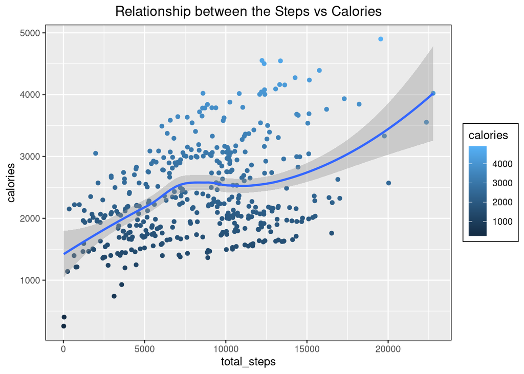

```r
  ggplot(data = merged_data, aes(x = total_steps, y = calories, color = calories))+
  geom_point()+
  geom_smooth()+
  labs(title = 'Relationship between the Steps vs Calories')+
  theme(plot.title = element_text(hjust = 0.5),
        panel.border = element_rect(color = 'black',  fill = NA),
        legend.background = element_blank(),
        legend.box.background = element_rect(colour = "black"))
```

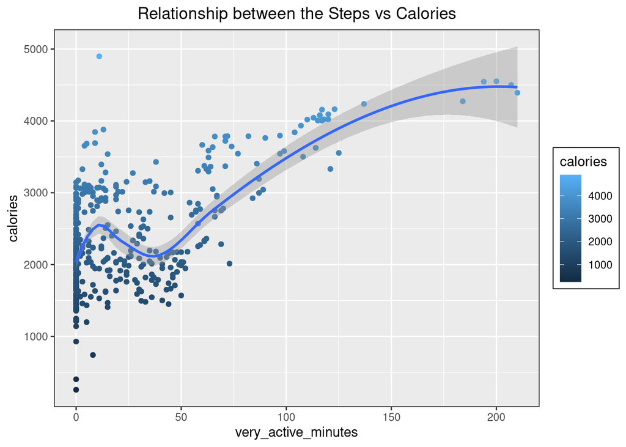

```r
ggplot(data = merged_data, aes(x = very_active_minutes, y = calories, color = calories))+
  geom_point()+
  geom_smooth()+
  labs(title = 'Relationship between the Steps vs Calories')+
  theme(plot.title = element_text(hjust = 0.5),
        panel.border = element_rect(color = 'black',  fill = NA),
        legend.background = element_blank(),
        legend.box.background = element_rect(colour = "black"))
```

Based on the plots above, there is a positive correlation between The Total_steps, Very_active_minutes and Calories. This means that the more active participants are, the more calories they burn.

4.1.2 : Exploring the relationship between steps taken in a day and sedentary minutes

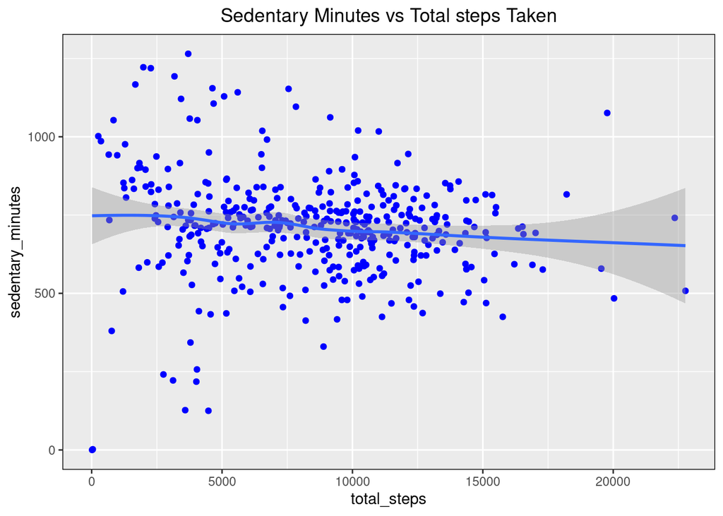

```r
ggplot(data = merged_data, aes(x = total_steps, y = sedentary_minutes))+
  geom_point(color = "blue")+
  geom_smooth()+
  labs(title = "Sedentary Minutes vs Total steps Taken")+
  theme(plot.title = element_text(hjust = 0.5),
        panel.border = element_rect(color = 'black',  fill = NA))
```